# Homework 3

Emily Mendez

### Problem 1

Examining German Credit dataset in asc file, all columns are German so translating to english. We are interested in the kredit column as our response.

**(a)**

```r
#loading in data
SGCreditData=read.table('/Users/admin/Documents/Csvv/SouthGermanCredit.asc',header=TRUE,sep = "")
```

```r
#creating a function to rename columns to English
ColeN=colnames(SGCreditData)
NColN=c("status","Duration","credit_history","Purpose","Amount","savings","employment_duration","installment_rate","Personal_status_sex","Other_debtors","Present_residence","Property","age","Other_installment_plans","housing","Number_credits","job","People_liable","telephone","foreign_worker","Credit_risk")

NewColName=function(var1,var2){
  ColName=as.character(var1)
  NewNam=as.character(var2)
  colnames(SGCreditData)[colnames(SGCreditData)== ColName] = NewNam
  return(SGCreditData)
}

NewSGCData=NewColName(ColeN,NColN)
```

[output not shown]

```r
library(caret)
# creating testing and validation data partition
trainIdx=createDataPartition(Credit_risk,p=0.7,list = FALSE, times = 1)
trainDF=NewSGCData[trainIdx,]
testDF=NewSGCData[-trainIdx,]
```

**(b)**

```r
#creating full logistic regression with credit_risk as our response
logit_full=glm(Credit_risk~. ,data=trainDF, family = "binomial")
summary(logit_full)
```

```
##
## Call:
## glm(formula = Credit_risk ~ ., family = "binomial", data = trainDF)
##
## Deviance Residuals:
##     Min       1Q   Median       3Q      Max
## -2.5322  -0.8125   0.4559   0.7672   1.9433
##
## Coefficients:
##                           Estimate Std. Error z value Pr(>|z|)
## (Intercept)             -1.487e+00  1.599e+00  -0.930 0.352421
## status                   5.395e-01  8.208e-02   6.573 4.94e-11 ***
## Duration                -2.607e-02  1.055e-02  -2.471 0.013466 *
## credit_history           4.593e-01  1.087e-01   4.224 2.40e-05 ***
## Purpose                  2.630e-02  3.528e-02   0.746 0.455949
## Amount                  -8.201e-05  4.798e-05  -1.709 0.087425 .
## savings                  1.707e-01  6.728e-02   2.538 0.011155 *
## employment_duration      6.311e-02  8.669e-02   0.728 0.466600
## installment_rate        -3.625e-01  1.021e-01  -3.551 0.000384 ***
## Personal_status_sex      3.534e-01  1.400e-01   2.525 0.011572 *
## Other_debtors            1.759e-01  1.992e-01   0.883 0.377247
## Present_residence        1.698e-02  9.268e-02   0.183 0.854666
## Property                -2.040e-01  1.113e-01  -1.832 0.066923 .
## age                      1.042e-02  9.670e-03   1.077 0.281279
## Other_installment_plans  1.935e-01  1.333e-01   1.451 0.146681
## housing                  3.296e-01  1.932e-01   1.706 0.088049 .
## Number_credits          -2.456e-01  2.059e-01  -1.193 0.232956
## job                     -9.888e-02  1.748e-01  -0.566 0.571692
## People_liable            3.866e-01  2.716e-01   1.424 0.154581
## telephone                3.999e-01  2.325e-01   1.720 0.085391 .
## foreign_worker          -7.959e-01  6.456e-01  -1.233 0.217587
## ---
## Signif. codes:  0 '***' 0.001 '**' 0.01 '*' 0.05 '.' 0.1 ' ' 1
##
## (Dispersion parameter for binomial family taken to be 1)
##
##     Null deviance: 856.90  on 699  degrees of freedom
## Residual deviance: 677.01  on 679  degrees of freedom
## AIC: 719.01
##
## Number of Fisher Scoring iterations: 5
```

There are only a couple variables with a significant pvalue, the pvalue we will be using is $0.05$ therefore, the variables that will be included in my reduced model will be status,Duration, credit_history, savings, installment_rate and Personal status sex.

```r
#creating reduced logistic regression with credit_risk as our response with significant variables
logit_reduced=glm(Credit_risk~ status + Duration + credit_history+ savings +  installment_rate+ Personal_status_sex, data=trainDF, family = "binomial")
summary(logit_reduced)
```

```
##
## Call:
## glm(formula = Credit_risk ~ status + Duration + credit_history +
##     savings + installment_rate + Personal_status_sex, family = "binomial",
##     data = trainDF)
##
## Deviance Residuals:
##     Min       1Q   Median       3Q      Max
## -2.4220  -0.8581   0.4843   0.7619   1.8025
##
## Coefficients:
##                      Estimate Std. Error z value Pr(>|z|)
## (Intercept)         -1.160387   0.519399  -2.234   0.0255 *
## status               0.539939   0.079284   6.810 9.75e-12 ***
## Duration            -0.038897   0.007789  -4.994 5.92e-07 ***
## credit_history       0.471037   0.092954   5.067 4.03e-07 ***
## savings              0.164773   0.064721   2.546   0.0109 *
## installment_rate    -0.259473   0.088025  -2.948   0.0032 **
## Personal_status_sex  0.337803   0.131739   2.564   0.0103 *
## ---
## Signif. codes:  0 '***' 0.001 '**' 0.01 '*' 0.05 '.' 0.1 ' ' 1
##
## (Dispersion parameter for binomial family taken to be 1)
##
##     Null deviance: 856.90  on 699  degrees of freedom
## Residual deviance: 699.95  on 693  degrees of freedom
## AIC: 713.95
##
## Number of Fisher Scoring iterations: 4
```

**(c)**

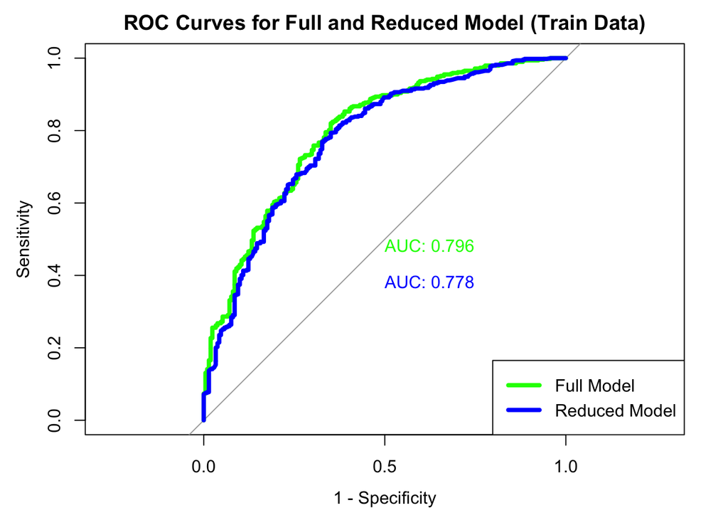

```r
#loading in library for ROC curve
library(pROC)
#plotting ROC curve
roc_full_training= roc(trainDF$Credit_risk,logit_full$fitted.values,plot=TRUE, print.auc=TRUE,
                       col="green", lwd =4, legacy.axes=TRUE,
                       main="ROC Curves for Full and Reduced Model (Train Data)")
roc_reduced_training = roc(trainDF$Credit_risk, logit_reduced$fitted.values, plot=TRUE,
                           print.auc=TRUE, col="blue",lwd = 4, print.auc.y=0.4, legacy.axes=TRUE,
                           add=TRUE)
legend("bottomright", legend=c("Full Model", "Reduced Model"), col=c("green", "blue"), lwd=4)
```

The full model gives us better predictions than the reduced but could be over fitted due to being training data.

```r
#predicting full and reduced models
pred_full = predict(logit_full, newdata=testDF, type="response")

pred_reduced = predict(logit_reduced,newdata=testDF, type="response")
```

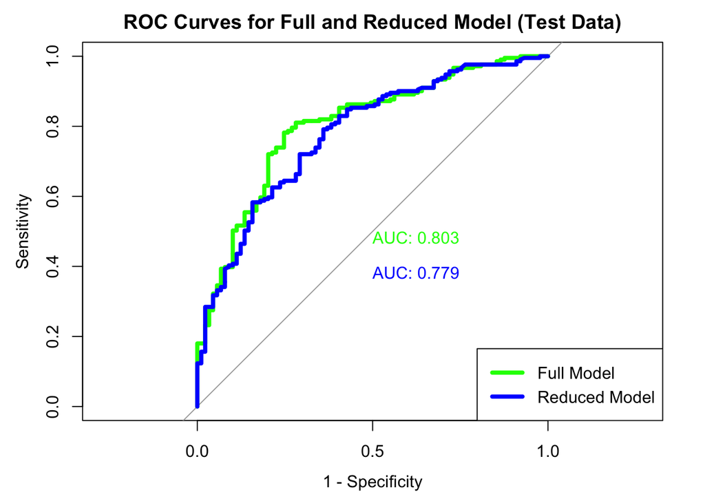

```r
#plotting roc curve based on validation data

roc_full_test = roc(testDF$Credit_risk, pred_full, plot=TRUE, print.auc=TRUE, col="green",
               lwd =4, legacy.axes=TRUE, main="ROC Curves for Full and Reduced Model (Test Data)")
roc_reduced_test = roc(testDF$Credit_risk, pred_reduced, plot=TRUE, print.auc=TRUE, col="blue",
               lwd = 4, print.auc.y=0.4, legacy.axes=TRUE, add=TRUE)
legend("bottomright", legend=c("Full Model", "Reduced Model"), col=c("green", "blue"), lwd=4)
```

Both models have approximately similar AUC. There is little underfitting on the training data. Because our models are of similar performance on the AUC, we have good accuracy and our reduced model doesn’t affect the predictive power much.

### Problem 2

**LDA**

```r
#loading in library for LDA and QDA
library(MASS)
#LDA Full
lda.fit=lda(Credit_risk~., data=trainDF)
lda.fit
```

```
## Call:
## lda(Credit_risk ~ ., data = trainDF)
##
## Prior probabilities of groups:
##         0         1
## 0.3014286 0.6985714
##
## Group means:
##     status Duration credit_history  Purpose   Amount  savings
## 0 1.919431 24.89573       2.127962 2.895735 3937.251 1.767773
## 1 2.844581 19.11043       2.721881 2.728016 3009.975 2.190184
##   employment_duration installment_rate Personal_status_sex Other_debtors
## 0            3.289100         3.146919            2.573460      1.146919
## 1            3.501022         2.946830            2.723926      1.157464
##   Present_residence Property      age Other_installment_plans  housing
## 0          2.857820 2.616114 33.72512                2.554502 1.890995
## 1          2.881391 2.269939 36.58691                2.723926 1.936605
##   Number_credits      job People_liable telephone foreign_worker
## 0       1.345972 2.966825      1.834123  1.379147       1.981043
## 1       1.443763 2.897751      1.840491  1.423313       1.948875
##
## Coefficients of linear discriminants:
##                                   LD1
## status                   4.789863e-01
## Duration                -2.448198e-02
## credit_history           4.019577e-01
## Purpose                  2.094294e-02
## Amount                  -7.080644e-05
## savings                  1.337973e-01
## employment_duration      5.401028e-02
## installment_rate        -3.034605e-01
## Personal_status_sex      3.108641e-01
## Other_debtors            1.956916e-01
## Present_residence        1.831970e-02
## Property                -1.916731e-01
## age                      5.417478e-03
## Other_installment_plans  1.523291e-01
## housing                  2.954338e-01
## Number_credits          -1.949202e-01
## job                     -6.011264e-02
## People_liable            3.265190e-01
## telephone                3.412205e-01
## foreign_worker          -3.505671e-01
```

```r
#LDA reduced
lda.fit.reduced=lda(Credit_risk~ status + Duration + credit_history+ savings +  installment_rate+ Personal_status_sex, data=trainDF)
lda.fit.reduced
```

```
## Call:
## lda(Credit_risk ~ status + Duration + credit_history + savings +
##     installment_rate + Personal_status_sex, data = trainDF)
##
## Prior probabilities of groups:
##         0         1
## 0.3014286 0.6985714
##
## Group means:
##     status Duration credit_history  savings installment_rate
## 0 1.919431 24.89573       2.127962 1.767773         3.146919
## 1 2.844581 19.11043       2.721881 2.190184         2.946830
##   Personal_status_sex
## 0            2.573460
## 1            2.723926
##
## Coefficients of linear discriminants:
##                             LD1
## status               0.51473793
## Duration            -0.03845336
## credit_history       0.43256583
## savings              0.14190811
## installment_rate    -0.23205257
## Personal_status_sex  0.32238844
```

```r
#LDA Confusion Matrix full
pLda=predict(lda.fit,testDF)
conf=table(pLda$class,testDF$Credit_risk)
conf
```

```
##
##       0   1
##   0  38  25
##   1  51 186
```

```r
#Accuracy of LDA model full
mean(pLda$class == testDF$Credit_risk)
```

```
## [1] 0.7466667
```

```r
#predict reduced
Reduced_lda=predict(lda.fit.reduced,testDF)
```

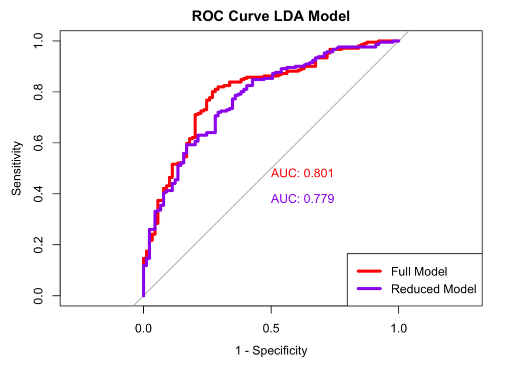

```r
#Receiver Operating Characteristic Curve for full and reduced LDA model
roc_full_lda = roc(testDF$Credit_risk , pLda$posterior[,2], plot=TRUE, print.auc=TRUE,
               col="red", lwd =4, legacy.axes=TRUE, main="ROC Curve LDA Model")
roc_reduced_lda = roc(testDF$Credit_risk , Reduced_lda$posterior[,2], plot=TRUE, print.auc=TRUE,
               col="purple", lwd =4,  print.auc.y=0.4, legacy.axes=TRUE, add=TRUE)
legend("bottomright", legend=c("Full Model", "Reduced Model"), col=c("red", "purple"), lwd=4)
```

**QDA**

```r
#Quadratic Discriminant Analysis: Full Model
qda.fit=qda(Credit_risk~., data=trainDF)
qda.fit
```

```
## Call:
## qda(Credit_risk ~ ., data = trainDF)
##
## Prior probabilities of groups:
##         0         1
## 0.3014286 0.6985714
##
## Group means:
##     status Duration credit_history  Purpose   Amount  savings
## 0 1.919431 24.89573       2.127962 2.895735 3937.251 1.767773
## 1 2.844581 19.11043       2.721881 2.728016 3009.975 2.190184
##   employment_duration installment_rate Personal_status_sex Other_debtors
## 0            3.289100         3.146919            2.573460      1.146919
## 1            3.501022         2.946830            2.723926      1.157464
##   Present_residence Property      age Other_installment_plans  housing
## 0          2.857820 2.616114 33.72512                2.554502 1.890995
## 1          2.881391 2.269939 36.58691                2.723926 1.936605
##   Number_credits      job People_liable telephone foreign_worker
## 0       1.345972 2.966825      1.834123  1.379147       1.981043
## 1       1.443763 2.897751      1.840491  1.423313       1.948875
```

```r
#Quadratic Discriminant Analysis: Reduced Model
qda.fit.reduced=qda(Credit_risk~ status + Duration + credit_history+ savings +  installment_rate+ Personal_status_sex, data=trainDF)
qda.fit.reduced
```

```
## Call:
## qda(Credit_risk ~ status + Duration + credit_history + savings +
##     installment_rate + Personal_status_sex, data = trainDF)
##
## Prior probabilities of groups:
##         0         1
## 0.3014286 0.6985714
##
## Group means:
##     status Duration credit_history  savings installment_rate
## 0 1.919431 24.89573       2.127962 1.767773         3.146919
## 1 2.844581 19.11043       2.721881 2.190184         2.946830
##   Personal_status_sex
## 0            2.573460
## 1            2.723926
```

```r
#Confusion Matrix for Full QDA model
pred.qda=predict(qda.fit,testDF)
confM=table(pred.qda$class,testDF$Credit_risk)
confM
```

```
##
##       0   1
##   0  46  40
##   1  43 171
```

```r
#Accuracy of full QDA model
mean(pred.qda$class == testDF$Credit_risk)
```

```
## [1] 0.7233333
```

```r
#reduced predict for reduced QDA model
Reduced_qda=predict(qda.fit.reduced,testDF)
```

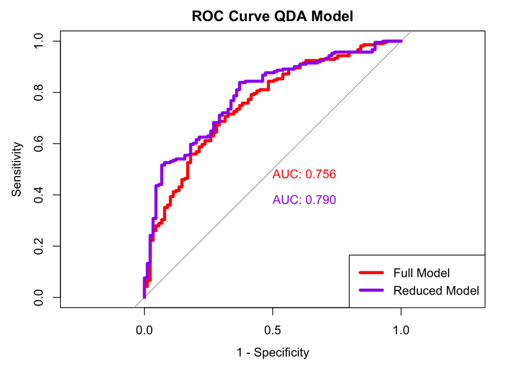

```r
#Receiver Operating Characteristic Curve for full and reduced QDA models

roc_full_qda = roc(testDF$Credit_risk , pred.qda$posterior[,2], plot=TRUE, print.auc=TRUE,
               col="red", lwd =4, legacy.axes=TRUE, main="ROC Curve QDA Model")
roc_reduced_qda= roc(testDF$Credit_risk , Reduced_qda$posterior[,2], plot=TRUE, print.auc=TRUE,
               col="purple", lwd =4,  print.auc.y=0.4, legacy.axes=TRUE, add=TRUE)
legend("bottomright", legend=c("Full Model", "Reduced Model"), col=c("red", "purple"), lwd=4)
```

**In conclusion** : The Accuracy of the QDA model is lower than the LDA model. The AUC of the QDA reduced model and the full model are approximately similar, so there appears to be similar performance in determining the AUC. Therefore, the reduced model doesnt really take away any significant predictive power in the model in QDA.